# Logrolling: Congressional Trading

*Tutorial by Justin Lumpkin and Daniel Wei*

"Logrolling" is a historical term refering to the trading of political votes. At present, the term "horse trading" is more commonly used to describe the same thing.

This project analyzes disclosures from the Stop Trading on Congressional Knowledge (STOCK) Act passed into law in 2012. The STOCK Act requires congresspeople to report stock trades (as well as some other financial transactions) over $1000 within 45 days of the trade date.

At the start of 2020, several Congress members were embroiled in a [scandal and legal investigation](https://www.cnn.com/2020/03/29/politics/justice-stock-trades-lawmakers-coronavirus/index.html) over alleged insider trading after receiving briefings about the coronavirus.

Prior reports such as those by [Unusual Whales](https://unusualwhales.com/i_am_the_senate/senate) have considered these disclosures. Our methodology differs in that we consider the full range of possible purchase/sale values rather than assuming only the upperbound as Unusual Whales reports does. We also consider the big picture of the full time period in which the disclosure requirements have been in place where Unusual Whales mainly considers one year at a time. Furthermore, Unusual Whales has a vested interest in marketing their product ([an ETF](https://unusualwhales.com/etfs) based on the stocks that politicians trade). Consequently, we would like to independently verify/qualify their results with a long-term focus in our methodology. Our data set only includes trades by senators, but Unusual Whales considers both senators and members of the House of Representatives. Lastly, we focus exclusively on stocks whereas Unusual Whales' analysis includes ETFs and other financial assets.

The STOCK Act is not considered to be very strict. "Congress and top Capitol Hill staff have violated the STOCK Act hundreds of times" by failing to disclose transactions on time according to a [Business Insider report](https://www.businessinsider.com/congress-stock-act-violations-penalties-consequences-2021-12). The fines for late reporting are relatively small (starting at $200), and there is no public record of whether these fines were paid. It is difficult (if not impossible) to determine the extent to which this has led to underreporting in our data set.

In response to all of these scandals, at least 14 separate bills to ban or limit congressional stock trading are circulating in the House or Senate. With the most successful proposals currently accumulating about 60 cosponsors.

**Our goal is to understand whether the senators that trade stocks are able to consistently beat the market.**

[This data set on kaggle](https://www.kaggle.com/datasets/heresjohnnyv/congress-investments) compiles all of the trade disclosures from US senators into a csv format.

We use the following libraries:

- `pandas` for storing data in dataframes
- `numpy` for fast numerical computations
- `yfinance` and `pandas_datareader.data`to access historical stock prices
- `matplotlib`, `matplotlib.pyplot`, and `seaborn` to create graphical visualizations
- `requests` and `bs4.BeautifulSoup` for retrieving data from an html format
- `datetime` for comparable date format
- `re` for cleaning data
- `scipy.optimize` for exponential regression
- `collections.default_dict` to improve the readability of our code when storing computed values in dictionaries
- `copy` to avoid overwriting prior computations

```python
# install yfinance and upgrade dependencies
!pip install yfinance --quiet 2> /dev/null
!pip install --upgrade pandas --quiet 2> /dev/null
!pip install --upgrade pandas-datareader --quiet 2> /dev/null
```

```python
# data structures and quality of life tools
import pandas as pd
import numpy as np
import re
import scipy.optimize
import datetime as dt
from collections import defaultdict
import copy

# libraries to collect data
import yfinance as yf
import requests
from bs4 import BeautifulSoup
import pandas_datareader.data as pdr

# libraries for visualization
import matplotlib.pyplot as plt
import matplotlib as mpl
# from matplotlib.pyplot import figure #Is this used?
import seaborn as sns
```

## Importing Data

### Trades

Next we read the financial disclosures from a [mirror](https://raw.githubusercontent.com/danielwei816/Logrollers/main/SenatorCleaned.csv) of the [original kaggle data set](https://www.kaggle.com/datasets/heresjohnnyv/congress-investments).

```python
# retrieve data
url = 'https://raw.githubusercontent.com/danielwei816/Logrollers/main/SenatorCleaned.csv'
disclosures = pd.read_csv(url)

# remove redundant index column
disclosures.drop("Unnamed: 0", inplace = True, axis = 1)
disclosures.head()
```

|  | Name | Transaction.Date | Owner | Ticker | Asset.Name | Asset.Type | Type | Amount | Comment |
| --- | --- | --- | --- | --- | --- | --- | --- | --- | --- |
| 0 | Sheldon Whitehouse | 11/25/2014 | Self | M | Macy's, Inc. (NYSE) | Stock | Purchase | 1001.0 | -- |
| 1 | Sheldon Whitehouse | 12/18/2014 | Self | BEAV | B/E Aerospace Inc. (NASDAQ) | Stock | Sale (Full) | 15001.0 | -- |
| 2 | Sheldon Whitehouse | 12/18/2014 | Self | KORS | Michael Kors Holdings Limited (NYSE) | Stock | Sale (Partial) | 1001.0 | -- |
| 3 | Sheldon Whitehouse | 12/18/2014 | Self | T | AT&T, Inc. (NYSE) | Stock | Purchase | 1001.0 | -- |
| 4 | Sheldon Whitehouse | 12/18/2014 | Self | KEYS | Keysight Technologies, Inc. (NYSE) | Stock | Sale (Full) | 1001.0 | Agilent Tech common stock completed a spinoff ... |

# Data Cleansing

## Isolating Stock Trades and Jim Inhofe

### Jim Inhofe missing data

One row in our data set does not record the amount. After some investigation through the [periodic transactions database](https://efdsearch.senate.gov/) we found that this trade was over $50,000,000.

Using the query:  
`First Name`: James  
`Last Name`: Inhofe  
`Report Type`: Periodic Transactions  
`Date Range`: 10-01-2015 to 10-31-2015 the single result is a report that notes a sale of WFM on October 5th, 2015 of over \$50,000,000. This is the only report of this amount in the data set, so naturally, we were suspicious. [OpenSecrets](https://www.opensecrets.org/personal-finances/james-inhofe/net-worth?cid=N00005582&year=2018) puts Jim Inhofe's current net worth at about \$5,000,000. It seems unlikely that he lost at least 90% of his net worth since 2015, but we could not find a more concrete reason to dispute this report, so we could not justify removing it from the data set.

```python
disclosures.loc[4825]
```

```
Name                 James M Inhofe
Transaction.Date          10/5/2015
Owner                          Self
Ticker                          WFM
Asset.Name                      WFM
Asset.Type                    Stock
Type                    Sale (Full)
Amount                          NaN
Comment                          --
Name: 4825, dtype: object
```

Some trades did not have a stock ticker. We remove these rows from the data set because we cannot determine what stock these trades are related to. This causes problems when computing the number of shares retained that senators have retained after partial transactions.

Our analysis focuses on the relationship between senator stock trades and the wider movement of the US Stock Market. Consequently, we filter out all data points that do not involve stock trades.

```python
# isolate stock trades
trades = disclosures[disclosures['Asset.Type'] == "Stock"]
# manually mark Inhofe's row
trades.at[4825, 'Amount'] = 50000000
# remove all trades without a stock ticker
trades = trades[trades['Ticker'].str.contains('--') == False]
trades.reset_index(inplace = True)
# drop previous index column
trades = trades.drop(['index'], axis=1)
len(trades)
```

```
12345
```

These changes leave us with 12345 disclosures.

## Column Names and Data Types

Next, we'll ensure that the columns in our `trades` Dataframe have reasonable names and data types for our analysis.

### Renaming Attributes and Values

We prefer the following updated names to clarify what each column represents without unnecessary information. Note that we replace the *Amount* column with the name "*Min_Value*" due to the transaction ranges discussed later.

```python
trades = trades.rename(columns={
  'Transaction.Date': 'Date',
  'Asset.Name': 'Asset_Name',
  'Asset.Type': 'Asset_Type',
  'Type': 'Transaction_Type',
  'Amount': 'Min_Value'
})
trades.head()
```

|  | Name | Date | Owner | Ticker | Asset_Name | Asset_Type | Transaction_Type | Min_Value | Comment |
| --- | --- | --- | --- | --- | --- | --- | --- | --- | --- |
| 0 | Sheldon Whitehouse | 11/25/2014 | Self | M | Macy's, Inc. (NYSE) | Stock | Purchase | 1001.0 | -- |
| 1 | Sheldon Whitehouse | 12/18/2014 | Self | BEAV | B/E Aerospace Inc. (NASDAQ) | Stock | Sale (Full) | 15001.0 | -- |
| 2 | Sheldon Whitehouse | 12/18/2014 | Self | KORS | Michael Kors Holdings Limited (NYSE) | Stock | Sale (Partial) | 1001.0 | -- |
| 3 | Sheldon Whitehouse | 12/18/2014 | Self | T | AT&T, Inc. (NYSE) | Stock | Purchase | 1001.0 | -- |
| 4 | Sheldon Whitehouse | 12/18/2014 | Self | KEYS | Keysight Technologies, Inc. (NYSE) | Stock | Sale (Full) | 1001.0 | Agilent Tech common stock completed a spinoff ... |

Below are the different types of transactions present in our data set:

```python
trades['Transaction_Type'].unique()
```

```
array(['Purchase', 'Sale (Full)', 'Sale (Partial)', 'Exchange'],
      dtype=object)
```

Notice that all sales are either "Sale (Full)" or "Sale (Partial)". Let's simplify these naming schemes into "Full" and "Partial".

```python
trades['Transaction_Type'] = trades['Transaction_Type'].apply(lambda item:
                            ("Full" if item == "Sale (Full)"
                             else "Partial" if item == "Sale (Partial)"
                             else item)
                            )
trades['Transaction_Type'].unique()
```

```
array(['Purchase', 'Full', 'Partial', 'Exchange'], dtype=object)
```

## Exchanging Stocks

```python
len(trades[trades["Transaction_Type"] == "Exchange"])
```

```
86
```

86 transactions in our data set are listed as exchanges. An exchange occurs when shares of one stock are traded directly for another stock. This most often occurs during company mergers or acquisitions or when a firm undergoes a name change.

### Translating Exchanges Into Purchases/Sales

Again, we'll be dealing with exchanges that occur within one transaction. To integrate these into our wider data set, we'll break these exchanges into two transactions: a purchase and a sale. Afterward, we'll simply insert these transactions into the `trades` dataframe.

Exchange transaction formatting is inconsistent. Some exchanges are listed in a single row with a line break between the ticker symbols in the `Ticker` column. Other exchanges have a pair of entries corresponding to each side of the trade with some indication in the comment which direction the trade moved.

In many cases, the data is not entirely clear on which stock was given and which stock was received. We were able to include the trades that listed both the exchanged and received stock in one row, but decided to drop the rest of the rows due to the formatting inconsistencies.  
*Recommendation:*  
We recommend auditing the existing reports to clarify the data and *issuing new requirements* on how exchanges are reported so that future analysis can work through a consistent format.

```python
# retrieve rows with an entire exchange
indexes = np.where((trades["Transaction_Type"] == "Exchange"))[0]
# create a regex that retrieves the new and old tickers + asset names
ticker_regex = re.compile("\^?(.*)\\r\\n\^?(.*)")
name_regex = re.compile("(.*) \(.*\\r\\n(.*) \(.*")

for i in indexes:
  # break the transaction into two matching trades
  sale = trades.loc[i].copy()
  purchase = trades.loc[i].copy()

  # match the expected format
  ticker_match = ticker_regex.match(trades.at[i, "Ticker"])
  name_match = name_regex.match(trades.at[i, "Asset_Name"])

  # remove the exchange from the data set regardless of format
  trades = trades.drop([i])
  if ticker_match != None:
    # add the purchase/sale pair if there was a match
    sale['Ticker'] = ticker_match.group(1)
    purchase['Ticker'] = ticker_match.group(2)
    sale['Asset_Name'] = name_match.group(1)
    purchase['Asset_Name'] = name_match.group(2)
    sale['Transaction_Type'] = "Full"
    purchase['Transaction_Type'] = "Purchase"
    trades = trades.append(sale)
    trades = trades.append(purchase)

# reset the table indices
trades.reset_index(inplace = True)
trades.drop(['index'], axis = 1, inplace = True)
trades.tail()
```

|  | Name | Date | Owner | Ticker | Asset_Name | Asset_Type | Transaction_Type | Min_Value | Comment |
| --- | --- | --- | --- | --- | --- | --- | --- | --- | --- |
| 12320 | Thad Cochran | 12/5/2017 | Self | APTV | Aptiv PLC | Stock | Purchase | 1001.0 | -- |
| 12321 | Thomas R Carper | 2/5/2021 | Spouse | DD | DuPont de Nemours, Inc. | Stock | Full | 1001.0 | -- |
| 12322 | Thomas R Carper | 2/5/2021 | Spouse | IFF | International Flavors & Fragrances Inc. | Stock | Purchase | 1001.0 | -- |
| 12323 | William F Hagerty IV | 5/17/2021 | Self | FL4.SG | FLIR SYSTEMS INC. Registered Sh | Stock | Full | 15001.0 | FLIR Systems Merger With Teledyne Asset Held i... |
| 12324 | William F Hagerty IV | 5/17/2021 | Self | TDY | Teledyne Technologies Incorporated | Stock | Purchase | 15001.0 | FLIR Systems Merger With Teledyne Asset Held i... |

The rows displayed above are examples of exchange transactions that were split into corresponding purchase and sale pairs.

### Data Types

Our current data types are as follows:

```python
trades.dtypes
```

```
Name                 object
Date                 object
Owner                object
Ticker               object
Asset_Name           object
Asset_Type           object
Transaction_Type     object
Min_Value           float64
Comment              object
dtype: object
```

**Date column:** Most of the columns make sense as strings, but we would prefer to have a `datetime` object for the date column to make it easier to interface with Yahoo Finance's data set.

**Min_Value column:** The STOCK Act does not require disclosures of exact transaction amounts. As a result, the 'Min_Value' column in the data set corresponds to the lower bound of the disclosure range that the trade belongs to. We cast it to a float.

```python
trades['Date'] = pd.to_datetime(trades['Date'])
trades['Min_Value'] = pd.to_numeric(trades['Min_Value'])
trades.dtypes
```

```
Name                        object
Date                datetime64[ns]
Owner                       object
Ticker                      object
Asset_Name                  object
Asset_Type                  object
Transaction_Type            object
Min_Value                  float64
Comment                     object
dtype: object
```

Our data spans nearly 10 years.

```python
trades['Date'].max()-trades['Date'].min()
```

```
Timedelta('3531 days 00:00:00')
```

## Comments on Comments

The table contains a comments column where senators can add any additional notes to their disclosure that they deem important to include. Because they are optional, we expect a relatively small fraction of disclosures to contain them.

About 7% (842/12325) of disclosures contained a comment. While this is a small minority, it prompted some further exploration in which we read each of the unique comments to determine if any factors were ones we wanted to include in our analysis. Many comments are repeated with only 124 unique comments in the data set.

Some example comments are displayed below.

```python
comments = trades[trades['Comment'] != "--"]["Comment"]
print(comments.unique()[0:10])
print(f"Total comments: {len(comments)}\
      \nUnique comments: {len(comments.unique())}\
      \nTotal rows: {len(trades)}")
```

```
['Agilent Tech common stock completed a spinoff on 10/22/14 to Keysight Tech'
 'KMB completed a spinoff of its health care business business now known as HYH on 11/01/14'
 'Dividend Reinvestment'
 '2015 Issued IR RSUs vested and actual shares issued; part of shares sold w/ remainder in UBS CSSP'
 '2016 Issued IR RSUs vested and actual shares issued; part of shares sold w/ remainder in UBS CSSP'
 'Transaction is due to sale of a security from redemption of incentive units vested on April 21, 2017'
 'Complete Disposition of Ingersoll Rand Stock'
 'Complete Disposition of Vulcan Materials Stock' 'Mandatory Cash Merger'
 'WTR-Aqua America, Inc name change to WTRG-Essential Utilities, Inc on 2/3/2020.']
Total comments: 842
Unique comments: 124
Total rows: 12325
```

After looking through the full list of unique comments, we did not find any that impacted our methodology, but some raised questions.

The comments roughly fall into the following categories. We create these categories qualitatively based on reading the comments, so any analysis over these attributes would require manually annotating the comments with their class. Additionally, because these comments are optional, it is possible that some of the trades with no listed comment fall into one of these classes. Similarly, some trades may belong to multiple categories. *A full list of unique comments is included in the* **Appendix**.

### Class 1: New Company Formation

- Spinoff companies
- Mergers and Acquisitions  
  These comments often correspond to exchange transactions with a comment describing a sell action under the old company name and a corresponding purchase under the new company name with the same amount.

### Class 2: Stock Manager

- Blind Trust
- Third party  
  These comments are likely attempts to counter critics that accuse the senators of trading on congressional knowledge.

### Class 3: Error

- Reporting is late
- Wrong asset type
- Wrong action ('partial sale' vs 'full sale')
- Trade was 'inadvertently omitted' from a previous report  
  It appears that each of the errors have been corrected in the data already. For example an error comment might read "this trade was erroneously listed as a purchase instead of a sale," but the corresponding entry would list the action as a sale.  
  In the cases marked as late disclosures, the comments often contain a mild apology for the delay. It would be interesting to examine whether the trades with reporting violations are statistically different in their returns, and which senators are the most frequent violators of reporting guidelines.

### Class 4: Not Required

- Trade is less than \$1,000
- Otherwise not required  
  Some Senators chose to report trades under \$1,000 even though this is not required under the STOCK Act. These trades erroneously had their stock range listed as \$1,001 to \$15,000 in the 'Amount' column. We note these entries (all of these comments contain 'less than') and correct the range to be \$1 to $1,000

### Class 5: Capital Source

- e.g. "this purchase is a dividend reinvestment"
- This asset was inherited  
  We do not think that these entries will be relevant to our analysis.

### Challenges

Again, the questions in this section would require manual coding of data into one of these classes. As a result, this is something that we leave to future work.

## Clarifying Transaction Ranges

Senators are not required to disclose the exact amount of money that was exchanged in a stock trade. Rather, they report the range in which their transaction amount fell into. Our current data set only reflects the lower bound of this range. We update our data set to reflect the full range by adding a lower bound, upper bound, and average transaction amount. This will allow us to determine conservative and liberal estimates of senator returns.

We use the average transaction amount to estimate an expected value of the return. This is imperfect because we do not know the distribution of trade amounts within each group. In general, one would expect that large trades are less common than small trades, meaning that each range is skewed right and that averaging the endpoints overestimates the average trade amount in each range. On the other hand, senators may be intentionally making multiple trades on the high end of a range to avoid having to report a higher amount range (which potentially corresponds to higher scrutiny). Furthermore, any number of interactions could affect the true value. As a result, we find that using the simplest approximation (while noting its limitations) is most appropriate.

The ranges for financial disclosures are as follows:

```
1. $1 - $1,000
2. $1,001 - $15,000
3. $15,001 - $50,000
4. $50,001 - $100,000
5. $100,001 - $250,000
6. $250,001 - $500,000
7. $500,001 - $1,000,000
8. $1,000,001 - $5,000,000
9. $5,000,001 - $25,000,000
10. $25,000,001 - $50,000,000
11. Over $50,000,000
```

*Note that, as previously mentioned, senators are not required to report transactions below 1001 dollars. Such transactions are denoted in the Comments.*

[Market Watch](https://www.marketwatch.com/story/u-s-lawmakers-traded-an-estimated-355-million-of-stock-last-year-these-were-the-biggest-buyers-and-sellers-11643639354) estimates that all congress people together sold $175 million in 2021.

Our only trade in the 'over \$50,000,000' range was a sale. As a result, we use $175 million as an upper bound for a possible stock trade.

```python
range_map = {
    1: 1000,
    1001: 15000,
    15001: 50000,
    50001: 100000,
    100001: 250000,
    250001: 500000,
    500001: 1000000,
    1000001: 5000000,
    5000001: 25000000,
    25000001: 50000000,
    50000000: 175000000
}

# correct amount lower bound for trades under $1000 as determined by the comment
trades['Min_Value'] = trades.apply(lambda row:
          1 if 'less than' in row['Comment'].lower() else row['Min_Value'], axis=1)

# compute maximum and average transaction amounts
trades['Max_Value'] = trades.apply(lambda row: range_map[row['Min_Value']], axis=1)
trades['Avg_Value'] = (trades['Min_Value'] + trades['Max_Value']) / 2
trades.head()
```

|  | Name | Date | Owner | Ticker | Asset_Name | Asset_Type | Transaction_Type | Min_Value | Comment | Max_Value | Avg_Value |
| --- | --- | --- | --- | --- | --- | --- | --- | --- | --- | --- | --- |
| 0 | Sheldon Whitehouse | 2014-11-25 | Self | M | Macy's, Inc. (NYSE) | Stock | Purchase | 1001.0 | -- | 15000 | 8000.5 |
| 1 | Sheldon Whitehouse | 2014-12-18 | Self | BEAV | B/E Aerospace Inc. (NASDAQ) | Stock | Full | 15001.0 | -- | 50000 | 32500.5 |
| 2 | Sheldon Whitehouse | 2014-12-18 | Self | KORS | Michael Kors Holdings Limited (NYSE) | Stock | Partial | 1001.0 | -- | 15000 | 8000.5 |
| 3 | Sheldon Whitehouse | 2014-12-18 | Self | T | AT&T, Inc. (NYSE) | Stock | Purchase | 1001.0 | -- | 15000 | 8000.5 |
| 4 | Sheldon Whitehouse | 2014-12-18 | Self | KEYS | Keysight Technologies, Inc. (NYSE) | Stock | Full | 1001.0 | Agilent Tech common stock completed a spinoff ... | 15000 | 8000.5 |

# Exploratory Analysis

## Frequency of Trades

### By Amount

First we determine the frequency of trades of each of the various amounts. **Note that the y-axis is on a log-scale**. We find that the number of trades decline rapidly as the size of the trade increases with the exception of the \$1-\$1000 range. This is almost certainly because reporting of trades under \$1000 is not required by the STOCK Act. We show exponential regression curves (which appear linear due to the log scale). The green curve models all of the data whereas the orange curve models only required disclosures. We fit both models because we expect the optional disclosures to be dramatically underreported.

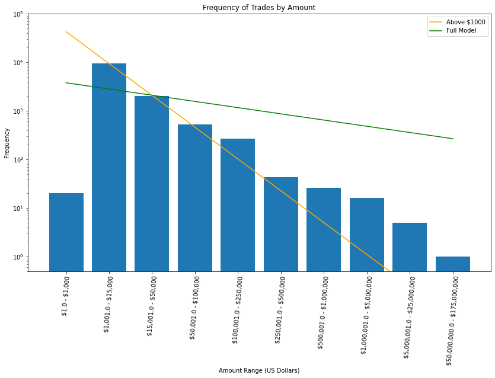

```
Modeling all of the data gives
	3774.76 * e ^ (-0.29x)

Modeling required disclosures gives
	42389.44 * e ^ (-1.51x)
```

```python
# obtain the sorted list of transaction amounts
ranges = list(set(trades['Min_Value']))
ranges.sort()

# find the frequency of each transaction amount
counts = [list(trades['Min_Value']).count(x) for x in ranges]

# fit exponential models to this data including and excluding the $1-$1000 range
xs = np.arange(0, len(counts))
def fit_exp(x, a, b):
    return a * np.exp(-b * x)
init = (1e4, 1) # start with values near those we expect
params1, cv = scipy.optimize.curve_fit(fit_exp, xs[1:], counts[1:], init)
params2, cv = scipy.optimize.curve_fit(fit_exp, xs, counts, init)

# create x axis labels
labels = [f"\${x:,} - \${range_map[x]:,}" for x in ranges]

f, ax = plt.subplots(figsize=(14, 8))

# plot bars and regression lines
plt.bar(xs, counts, tick_label = labels, log = True)
plt.plot(xs, fit_exp(xs, *params1), label = "Above $1000", color = "orange")
plt.plot(xs, fit_exp(xs, *params2), label = "Full Model", color = "green")

# format and label the graph
plt.xticks(ticks = xs, rotation = 85)
plt.ylim(0.5, 1e5)
plt.title("Frequency of Trades by Amount")
plt.xlabel("Amount Range (US Dollars)")
plt.ylabel("Frequency")
plt.legend()
plt.show()

# print equations
print(f"Modeling all of the data gives\n\t{params2[0]:.2f} * e ^ (-{params2[1]:.2f}x)")
print(f"\nModeling required disclosures gives\n\t{params1[0]:.2f} * e ^ (-{params1[1]:.2f}x)")
```

The orange line appears to have a much better overall fit. While it appears to be far off for the rightmost bars, this is due to the log scale of the y-axis.

While regressing against the index of an ordinal $x$ variable is not particularly meaningful, the orange line is consistent with small transactions being much more common than large transactions. This suggests that we should expect a much larger share of the trades to be in the \$1 to \$1000 range if all trades were required to be disclosed.

This contextualizes our later findings because our computations assume that we have access to all of the trades over the time period of our data set.

*Recommendation:*  
We would like to see new reporting requirements so that senators must report all individual stock trades regardless of the amount. This will improve the accuracy of our return computations and allow future researchers to compare these trades to larger ones (in terms of the percent return or other metrics).

### By Senator

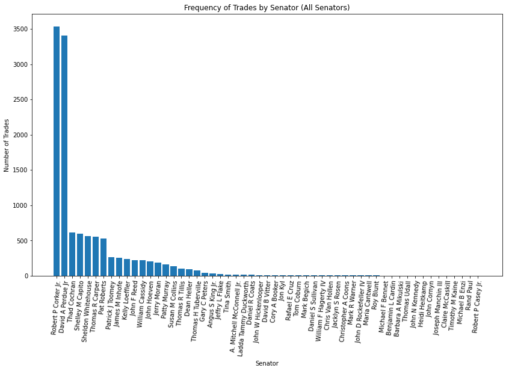

```
55 unique senators
The most frequent traders have made as many as 3537 trades
```

```python
# get unique senator names
names = list(set(trades['Name']))

# find the frequency of each senator in the data
counts = [list(trades['Name']).count(x) for x in names]

# sort from largest frequency to smallest frequency
trade_freq = dict(sorted(zip(names, counts), \
                         key = lambda item: item[1], reverse=True))

# plot bars
f, ax = plt.subplots(figsize=(14, 8))
plt.bar(trade_freq.keys(), trade_freq.values())

# format and label the graph
plt.xticks(ticks = list(trade_freq.keys()), rotation = 85)
plt.title("Frequency of Trades by Senator (All Senators)")
plt.xlabel("Senator")
plt.ylabel("Number of Trades")
plt.show()

# print key statistics
print(f"{len(names)} unique senators")
print(f"The most frequent traders have made as many as {max(counts)} trades")
```

Only 55 total senators have disclosed trades since the passage of the STOCK Act. The most frequent traders in the data set have made about one trade per calendar day over the roughly ten years that we have data (of course, the market is not open every day).

Because so many senators report a very small number of trades, I plot the top 7 traders and the rest of the senators separately.

#### Top Traders

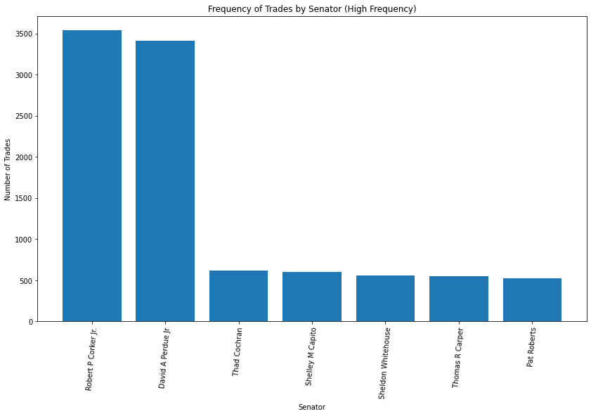

```
[(' Robert P Corker Jr.', 3537),
 (' David A Perdue Jr', 3410),
 (' Thad Cochran', 619),
 (' Shelley M Capito', 598),
 (' Sheldon Whitehouse', 560),
 (' Thomas R Carper', 553),
 (' Pat Roberts', 528)]
```

```python
top_traders = 7
# plot bars
f, ax = plt.subplots(figsize=(14, 8))
plt.bar(list(trade_freq.keys())[:top_traders], list(trade_freq.values())[:top_traders])

# format and label the graph
plt.xticks(ticks = list(trade_freq.keys())[:top_traders], rotation = 85)
plt.title("Frequency of Trades by Senator (High Frequency)")
plt.xlabel("Senator")
plt.ylabel("Number of Trades")
plt.show()

# print the top traders with number of trades
[(k,v) for k,v in trade_freq.items()][:top_traders]
```

#### Other Traders

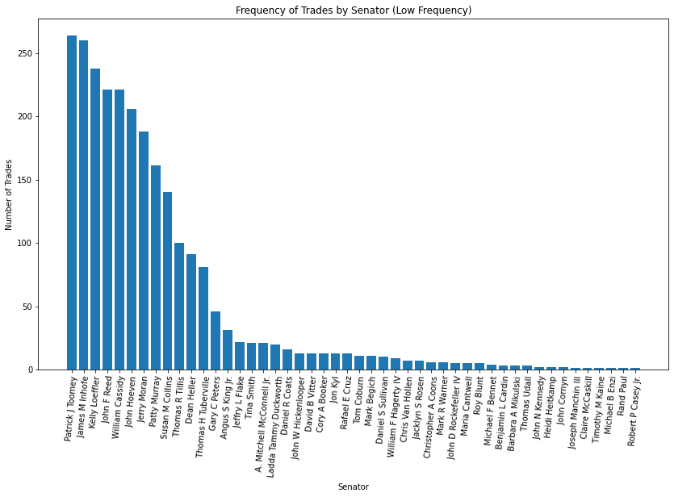

```python
# plot bars
f, ax = plt.subplots(figsize=(14, 8))
plt.bar(list(trade_freq.keys())[top_traders:], list(trade_freq.values())[top_traders:])

# format and label the graph
plt.xticks(ticks = list(trade_freq.keys())[top_traders:], rotation = 85)
plt.title("Frequency of Trades by Senator (Low Frequency)")
plt.xlabel("Senator")
plt.ylabel("Number of Trades")
plt.show()
```

Astonishingly, Bob Corker and David Perdue made roughly 56% (6947/12325) of the disclosed trades in our data set. This is an important limitation on the applicability of our findings to other senators.

## Volume of Trades

Using the conservative estimates, senators have traded over \$200 million during the disclosure period. Jim Inhofe is the top trader at over \$58 million!

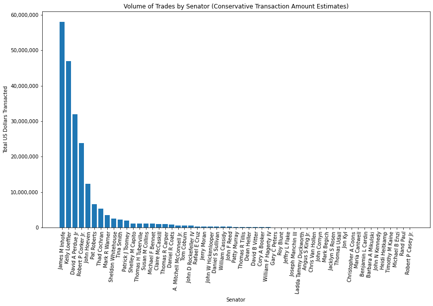

```
Single senators have traded as much as $58,042,259.00
Senators traded a total of $207,349,324.00
```

```python
# get unique senator names
names = list(set(trades['Name']))

# find the volume for each senator
volumes = [trades[trades['Name'] == x]['Min_Value'].sum() for x in names]

# sort from largest volume to smallest volume
trade_vol = dict(sorted(zip(names, volumes), \
                         key = lambda item: item[1], reverse=True))

# plot bars
f, ax = plt.subplots(figsize=(14, 8))
plt.bar(trade_vol.keys(), trade_vol.values(), log = False)

# format and label the graph
plt.xticks(ticks = list(trade_vol.keys()), rotation = 85)
ax.ticklabel_format(axis = 'y', style = 'plain')
ax.yaxis.set_major_formatter(mpl.ticker.StrMethodFormatter('{x:,.0f}'))
plt.title("Volume of Trades by Senator (Conservative Transaction Amount Estimates)")
plt.xlabel("Senator")
plt.ylabel("Total US Dollars Transacted")
plt.show()

# print key statistics
print(f"Single senators have traded as much as ${max(volumes):,.2f}")
print(f"Senators traded a total of ${sum(volumes):,.2f}")
```

Using the average estimates, the Senate has traded nearly half a billion dollars led by Jim Inhofe with nearly \$126 million in trades during the disclosure period.

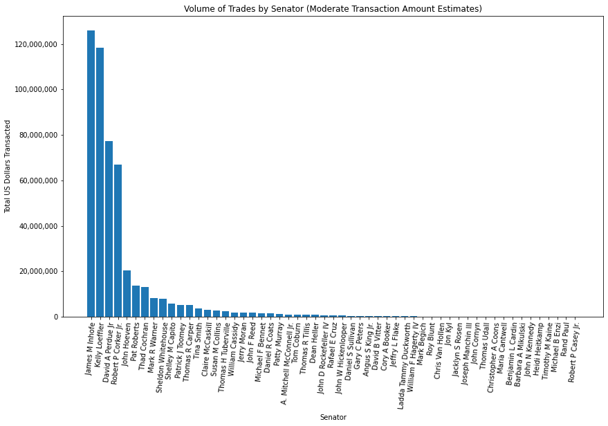

```
Single senators have traded as much as $125,998,629.50
Senators traded a total of $497,987,162.00
```

```python
# get unique senator names
names = list(set(trades['Name']))

# find the volume for each senator
volumes = [trades[trades['Name'] == x]['Avg_Value'].sum() for x in names]

# sort from largest volume to smallest volume
trade_vol = dict(sorted(zip(names, volumes), \
                         key = lambda item: item[1], reverse=True))

# plot bars
f, ax = plt.subplots(figsize=(14, 8))
plt.bar(trade_vol.keys(), trade_vol.values(), log = False)

# format and label the graph
plt.xticks(ticks = list(trade_vol.keys()), rotation = 85)
ax.ticklabel_format(axis = 'y', style = 'plain')
ax.yaxis.set_major_formatter(mpl.ticker.StrMethodFormatter('{x:,.0f}'))
plt.title("Volume of Trades by Senator (Moderate Transaction Amount Estimates)")
plt.xlabel("Senator")
plt.ylabel("Total US Dollars Transacted")
plt.show()

# print key statistics
print(f"Single senators have traded as much as ${max(volumes):,.2f}")
print(f"Senators traded a total of ${sum(volumes):,.2f}")
```

Using the liberal estimates, senators as a whole have traded nearly \$800 million led by Jim Inhofe with over \$190 million in trades during the disclosure period.

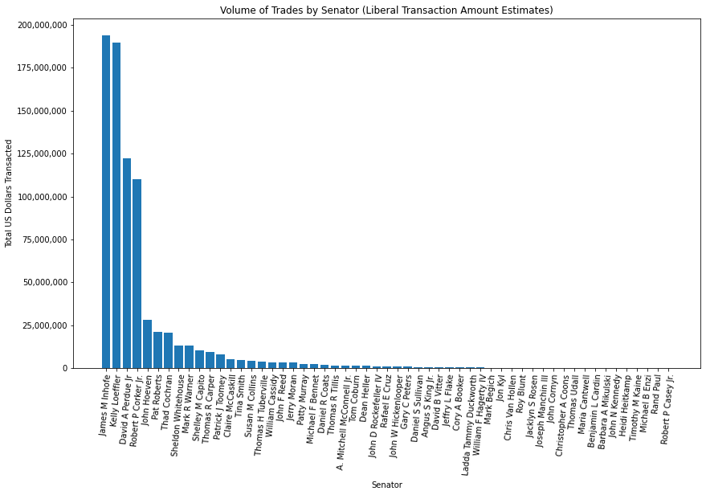

```
Single senators have traded as much as $193,955,000
Senators traded a total of $788,625,000
```

```python
# get unique senator names
names = list(set(trades['Name']))

# find the volume for each senator
volumes = [trades[trades['Name'] == x]['Max_Value'].sum() for x in names]

# sort from largest volume to smallest volume
trade_vol = dict(sorted(zip(names, volumes), \
                         key = lambda item: item[1], reverse=True))

# plot bars
f, ax = plt.subplots(figsize=(14, 8))
plt.bar(trade_vol.keys(), trade_vol.values(), log = False)

# format and label the graph
plt.xticks(ticks = list(trade_vol.keys()), rotation = 85)
ax.ticklabel_format(axis = 'y', style = 'plain')
ax.yaxis.set_major_formatter(mpl.ticker.StrMethodFormatter('{x:,.0f}'))
plt.title("Volume of Trades by Senator (Liberal Transaction Amount Estimates)")
plt.xlabel("Senator")
plt.ylabel("Total US Dollars Transacted")
plt.show()

# print key statistics
print(f"Single senators have traded as much as ${max(volumes):,}")
print(f"Senators traded a total of ${sum(volumes):,}")
```

# Analyzing Returns

## Accessing Stock Price Data

We downloaded historical stock price data from the yfinance database. This took about 10 minutes to run, so we saved the data to a csv file and [uploaded it to github](https://raw.githubusercontent.com/danielwei816/Logrollers/main/tickers.csv) for faster retrieval. Below is the code we originally used to retrieve the prices.

```python
# stock_list = list(trades["Ticker"].unique())
# data = yf.download(stock_list, start=trades["Date"].min(), end=trades["Date"].max() + dt.timedelta(days=1))
# data['Adj Close'].reset_index().to_csv("tickers.csv")
```

The dataframe below has one date per row with the each ticker as a column.

```python
price_history = pd.read_csv("https://raw.githubusercontent.com/danielwei816/Logrollers/main/tickers.csv")
price_history['Date'] = pd.to_datetime(price_history['Date'])
price_history.drop(['Unnamed: 0'], axis = 1, inplace = True)
price_history.tail()
```

|  | Date | A | AA | AAGIY | AAL | AAN | AAON | AAPL | AAT | ABB | ... | YUM | YUMC | ZAYO | ZBH | ZION | ZIOP | ZM | ZMH | ZNGA | ZTS |
| --- | --- | --- | --- | --- | --- | --- | --- | --- | --- | --- | --- | --- | --- | --- | --- | --- | --- | --- | --- | --- | --- |
| 2495 | 2021-07-26 | 149.865753 | 38.875099 | 47.913841 | 22.080000 | 27.719999 | 60.000000 | 148.143631 | 35.804115 | 36.950001 | ... | 121.938988 | 64.216637 | NaN | 154.444763 | 50.569202 | NaN | 373.140015 | NaN | 10.35 | 200.258850 |
| 2496 | 2021-07-27 | 149.566513 | 38.186604 | 45.772606 | 21.459999 | 30.129999 | 59.869999 | 145.936234 | 35.960251 | 36.830002 | ... | 123.944145 | 60.990372 | NaN | 157.530762 | 50.765667 | NaN | 367.540009 | NaN | 10.14 | 201.305908 |
| 2497 | 2021-07-28 | 151.072662 | 38.146690 | 45.673016 | 21.629999 | 28.639999 | 60.840000 | 144.156403 | 36.253006 | 36.840000 | ... | 121.109268 | 62.105621 | NaN | 157.259888 | 51.433636 | NaN | 369.489990 | NaN | 10.25 | 202.702011 |
| 2498 | 2021-07-29 | 152.279572 | 39.284206 | 47.127060 | 21.170000 | 28.520000 | 62.110001 | 144.812653 | 36.321320 | 37.009998 | ... | 128.715027 | 62.135498 | NaN | 157.434021 | 51.905140 | NaN | 386.019989 | NaN | 10.21 | 203.549606 |
| 2499 | 2021-07-30 | 152.838135 | 40.062508 | 47.744534 | 20.379999 | 28.870001 | 62.150002 | 145.031403 | 36.038322 | 36.619999 | ... | 129.781799 | 61.926384 | NaN | 158.091843 | 51.227352 | NaN | 378.100006 | NaN | 10.10 | 202.133591 |

5 rows × 1199 columns

## Calculating Number of Shares Per Trade

We are interested in computing the value of each senator's retained assets at the end of the data set.

To do this we access the price of the stock for each transaction, and we use the minimum, average, and maximum transaction amounts to determine the minimum, average, and maximum number of shares transacted respectively. $$number\_of\_shares = \cfrac{total\_value}{price}$$

```python
trades["Min_Shares"] = [np.nan] * len(trades)
trades["Avg_Shares"] = [np.nan] * len(trades)
trades["Max_Shares"] = [np.nan] * len(trades)

for i, row in trades.iterrows():
  ticker = row["Ticker"]
  start = row["Date"]

  # retrieve price for the stock on the transaction date
  price_df = price_history[price_history['Date'] == row["Date"]].reset_index()

  # if found, use this price to compute {min, avg, max} shares
  if len(price_df) == 1:

    price = price_df.loc[0, row["Ticker"]]

    if not np.isnan(price):
      trades.at[i, "Min_Shares"] = row["Min_Value"] / price
      trades.at[i, "Avg_Shares"] = row["Avg_Value"] / price
      trades.at[i, "Max_Shares"] = row["Max_Value"] / price
```

```python
len(trades[~trades['Max_Shares'].isnull()])
```

```
10019
```

We are left with roughly 10,000 transactions that have shares numbers computed. We are not able to compute data for tickers and dates that `yfinance` does not have data for. This may occur if

- the ticker is not listed on an exchange that `yfinance` tracks
- `yfinance` does not track the ticker
- `yfinance` is missing data in the specified date range for the specified ticker

Knowing the number of shares allows us to compute unrealized gains (the increase in value of assets that they have not yet sold). We can also determine (in some cases) that senators must have acquired some stock before the disclosure requirements went into effect.

## Computing Total Returns

Our approach to computing total returns is using the formula: $$return = total\_sales - total\_purchases + current\_holdings - initial\_holdings$$

The value of *total_sales* is computed by summing the (minumum, average, and maximum) value of each transaction with "Full" or "Partial" sale in the `Transaction_Type` column. Similarly, *total_purchases* is computed by summing the possible values of each transaction with a "Purchase" action.

We compute the (minumum, average, and maximum) value of current holdings using the (minumum, average, and maximum) number of shares retained times the price on the last day that we have data for.

If we compute that a congress person has a negative number of shares retained, then we assume that they purchased that quantity of shares prior to the start of the disclosure requirements.

This approximation for shares retained (and for implied prior holdings) is imperfect because transactions under \$1000 are not reported and the minimum and maximum possible values can vary greatly. We cannot determine whether smaller transactions are causing errors in our estimates from this data.

First, we compute the difference between purchase and sale values. This is roughly equivalent to the *realized gains* (the profit from assets that have been sold) for each `(senator, stock)` pair, but it also includes the cost of purchasing assets that have not yet been sold.

```python
# nested dictionary: min_real_gains[senator][ticker]
# will return the minimum profit for that senator on that stock
# the default value of min_real_gains is a defaultdict with default 0
min_real_gains = defaultdict(lambda: defaultdict(float))
max_real_gains = defaultdict(lambda: defaultdict(float))
avg_real_gains = defaultdict(lambda: defaultdict(float))

# store total cost of purchasing stocks for each senator default is 0
min_cost = defaultdict(float)
max_cost = defaultdict(float)
avg_cost = defaultdict(float)

for (senator, stock), group in trades.groupby(['Name', 'Ticker']):
  # sum purchase value
  total_purchases_min = sum(group[group['Transaction_Type'] == 'Purchase']['Min_Value'])
  total_purchases_max = sum(group[group['Transaction_Type'] == 'Purchase']['Max_Value'])
  total_purchases_avg = sum(group[group['Transaction_Type'] == 'Purchase']['Avg_Value'])

  # sum sale values
  total_sales_min = sum(group[(group['Transaction_Type'] == 'Full') |
      (group['Transaction_Type'] == 'Partial')]['Min_Value'])
  total_sales_max = sum(group[(group['Transaction_Type'] == 'Full') |
      (group['Transaction_Type'] == 'Partial')]['Max_Value'])
  total_sales_avg = sum(group[(group['Transaction_Type'] == 'Full') |
      (group['Transaction_Type'] == 'Partial')]['Avg_Value'])

  # record the profit for the current (senator, stock) combination
  min_real_gains[senator][stock] = total_sales_min - total_purchases_max
  max_real_gains[senator][stock] = total_sales_max - total_purchases_min
  avg_real_gains[senator][stock] = total_sales_avg - total_purchases_avg

  # track total dollars invested for this senator
  min_cost[senator] += total_purchases_min
  max_cost[senator] += total_purchases_max
  avg_cost[senator] += total_purchases_avg
```

## Computing Shares Retained

As previously stated, senators may not sell 100% of their assets within this data set, so we compute the number of shares retained.

The number of shares held for each `(senator, stock)` pair is the total number of shares purchased minus the total number of shares sold. We take the *minimum* purchases minus the *maximum* sales to obtain the minimum number of shares retained and vise versa for the maximum number of shares retained.

```python
# nested dictionary: min_shares_held[senator][ticker] will return
# the minimum number of shares retained at the end of the disclosure period
min_shares_held = defaultdict(lambda: defaultdict(float))
max_shares_held = defaultdict(lambda: defaultdict(float))
avg_shares_held = defaultdict(lambda: defaultdict(float))

for i, row in trades.iterrows():
  senator = row['Name']
  stock = row['Ticker']
  transaction_type = row['Transaction_Type']
  trade_min_shares = row['Min_Shares'] if not np.isnan(row['Min_Shares']) else 0
  trade_max_shares = row['Max_Shares'] if not np.isnan(row['Max_Shares']) else 0
  trade_avg_shares = row['Avg_Shares'] if not np.isnan(row['Avg_Shares']) else 0

  # Update number of shares held
  if transaction_type == 'Purchase':
    min_shares_held[senator][stock] += trade_min_shares
    max_shares_held[senator][stock] += trade_max_shares
    avg_shares_held[senator][stock] += trade_avg_shares
  else:
    min_shares_held[senator][stock] -= trade_max_shares
    max_shares_held[senator][stock] -= trade_min_shares
    avg_shares_held[senator][stock] -= trade_avg_shares
```

## Value of Holdings

We compute the value of the shares retained.

*Current Holding Value*

- If the number of shares retained is positive, we consider it a current holding and multiply it by the most recent price to estimate its value.
- This is added to the senator's profits as unrealized gains $$unrealized\_gains = shares\_retained \times current\_price$$
- These gains will be positive because `shares_retained` is positive

*Initial Holding Value*

- If the number of shares retained is negative, we assume that they purchased this number of shares before the STOCK Act went into effect, so we multiply this by the value of the stock at the begining of our data set.
- this is added (it is a negative number) to a senator's profits to adjust for unrecorded investment costs $$unrealized\_gains = shares\_retained \times initial\_price$$
- These gains will be negative because `shares_retained` is negative
- In this case we must add $|unrealized\_gains|$ to the senator's total investment amount to account for this implied purchase.

The above values are added to the previously computed realized gains to obtain total gains.

Of course we cannot compute the value change of assets that were neither purchased nor sold during the disclosure period, and we cannot account for any transactions under \$1000 that may have occured.

```python
start_date = trades['Date'].min()
end_date = trades['Date'].max()

min_total_gains = copy.deepcopy(min_real_gains)
max_total_gains = copy.deepcopy(max_real_gains)
avg_total_gains = copy.deepcopy(avg_real_gains)

for senator in min_shares_held:
  min_shares = min_shares_held[senator]
  max_shares = max_shares_held[senator]
  avg_shares = avg_shares_held[senator]

  # loop through the tickers. These are the same for min, avg, max shares
  for stock in min_shares:
    # retreive start and end prices of the stock over the disclosure period
    curr_price = price_history[price_history['Date'] == end_date][stock].values[0]
    start_price = price_history[price_history['Date'] == start_date][stock].values[0]

    min_retained = min_shares[stock]
    max_retained = max_shares[stock]
    avg_retained = avg_shares[stock]
    # calculate value of current/initial assets
    min_unreal_gains = min_retained * curr_price if min_retained > 0 else min_retained * start_price
    max_unreal_gains = max_retained * curr_price if max_retained > 0 else max_retained * start_price
    avg_unreal_gains = avg_retained * curr_price if avg_retained > 0 else avg_retained * start_price

    # adjust each senator's total cost if they have an initial asset
    min_cost[senator] += -min_unreal_gains if min_unreal_gains < 0 else 0
    max_cost[senator] += -max_unreal_gains if max_unreal_gains < 0 else 0
    avg_cost[senator] += -avg_unreal_gains if avg_unreal_gains < 0 else 0

    # sum realized and unrealized gains to get total gains
    min_total_gains[senator][stock] += min_unreal_gains if not np.isnan(min_unreal_gains) else 0
    max_total_gains[senator][stock] += max_unreal_gains if not np.isnan(max_unreal_gains) else 0
    avg_total_gains[senator][stock] += avg_unreal_gains if not np.isnan(avg_unreal_gains) else 0
```

## Do Senators Pick Better Stocks?

### Comparing Percent Returns

Let's see how the group of stocks that Senators have chosen to invest in have performed relative to the S&P 500. We'll start by aggregating the prices of all of the Senator stocks on each day. We use the S&P 500 because it is a standard market benchmark.

```python
# sum all senator stock prices for all dates and compute percent return
price_history['agg_price'] = price_history.sum(axis=1, numeric_only=True)
start_agg_price = price_history.iloc[1]['agg_price']
end_agg_price = price_history.iloc[len(price_history)-1]['agg_price']
(end_agg_price - start_agg_price) / start_agg_price * 100
```

```
102.25719828397546
```

Now, let's get the price data for the S&P 500 over the same time period.

```python
sp500 = yf.download(['^GSPC'], start=trades["Date"].min(), end=trades["Date"].max() + dt.timedelta(days=1)).reset_index()
sp500 = sp500[['Date', 'Adj Close']]
sp500 = sp500.rename(columns={'Adj Close': 'Price'})
start_sp500_price = sp500.loc[1, 'Price']
end_sp500_price = sp500.loc[len(sp500) - 1, 'Price']
sp500_change = (end_sp500_price - start_sp500_price) / start_sp500_price * 100
sp500_change
```

```
[*********************100%***********************]  1 of 1 completed
```

```
252.47801880667592
```

This is actually quite surprising. The 1198 stocks that Senators have chosen to invest in grew by approximately **102.26%**, whereas the S&P 500 gained approximately **252.48%** over the same time period. Based on the disclosures, it seems that the stocks that senators chose significantly underperform the S&P 500!

### Visualizing Senator Stocks vs. S&P 500

Now, let's try to visualize the percent gain for Senator stocks and the S&P500 over time.

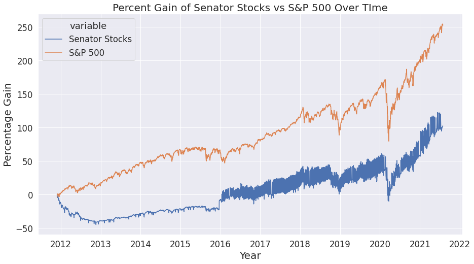

```python
# calculate percent gain for each group on each date
price_history['percent_gain'] = (price_history['agg_price'] - start_agg_price) / start_agg_price * 100
sp500['percent_gain'] = (sp500['Price'] - start_sp500_price) / start_sp500_price * 100

# plot lines
pct_merged = pd.merge(price_history[['Date', 'percent_gain']], sp500[['Date', 'percent_gain']], on=['Date'])
pct_merged = pct_merged.rename(columns={'percent_gain_x': 'Senator Stocks',
                  'percent_gain_y': 'S&P 500'})
sns.set(rc = {'figure.figsize':(15,8)},font_scale=1.5)
pct_plot = sns.lineplot(x='Date', y='value', hue='variable',
             data=pd.melt(pct_merged, ['Date']))

# label plot
pct_plot.set_xlabel("Year", fontsize = 20)
pct_plot.set_ylabel("Percentage Gain", fontsize = 20)
pct_plot.set_title('Percent Gain of Senator Stocks vs S&P 500 Over TIme', fontsize = 20)
```

## Individual Senators vs. S&P500

We've shown that the stocks traded by senators are not outperforming the market with their trades over \$1000. However, some individual Senators do outperform the S&P 500. According to [The American Enterprise Institute](https://www.aei.org/carpe-diem/more-evidence-that-its-really-hard-to-beat-the-market-over-time-95-of-finance-professionals-cant-do-it/), only about 10% of professional active investment fund managers beat the market over a 10 year period.

First we compute the total gains for each senator by summing the gains across all stocks.

```python
min_total_returns = {}
max_total_returns = {}
avg_total_returns = {}
# calculating total returns for each senator across all stocks purchased/sold
for senator in min_total_gains:
  min_total_returns[senator] = sum([val for val in min_total_gains[senator].values()])
  max_total_returns[senator] = sum([val for val in max_total_gains[senator].values()])
  avg_total_returns[senator] = sum([val for val in avg_total_gains[senator].values()])
```

We compute the return on investment (ROI) for each Senator and compare those values to the S&P 500. We use the formula: $$ROI = \cfrac{total\_gains}{total\_cost}$$

```python
min_roi = {}
max_roi = {}
avg_roi = {}
# compute percent retrusn for all senators across all investments
for senator in min_total_returns:
  min_roi[senator] = min_total_returns[senator]/max_cost[senator] * 100
  max_roi[senator] = max_total_returns[senator]/min_cost[senator] * 100
  avg_roi[senator] = avg_total_returns[senator]/avg_cost[senator] * 100

# sort dictionaries based on the average roi
sorted_avg_roi = {k: v for k, v in sorted(avg_roi.items(), key=lambda item: avg_roi[item[0]], reverse=True)}
sorted_min_roi = {k: v for k, v in sorted(min_roi.items(), key=lambda item: avg_roi[item[0]], reverse=True)}
sorted_max_roi = {k: v for k, v in sorted(max_roi.items(), key=lambda item: avg_roi[item[0]], reverse=True)}
```

We show the minimum, average, and maximum returns for each senator sorted from largest to smallest average percent return.

[output not shown]

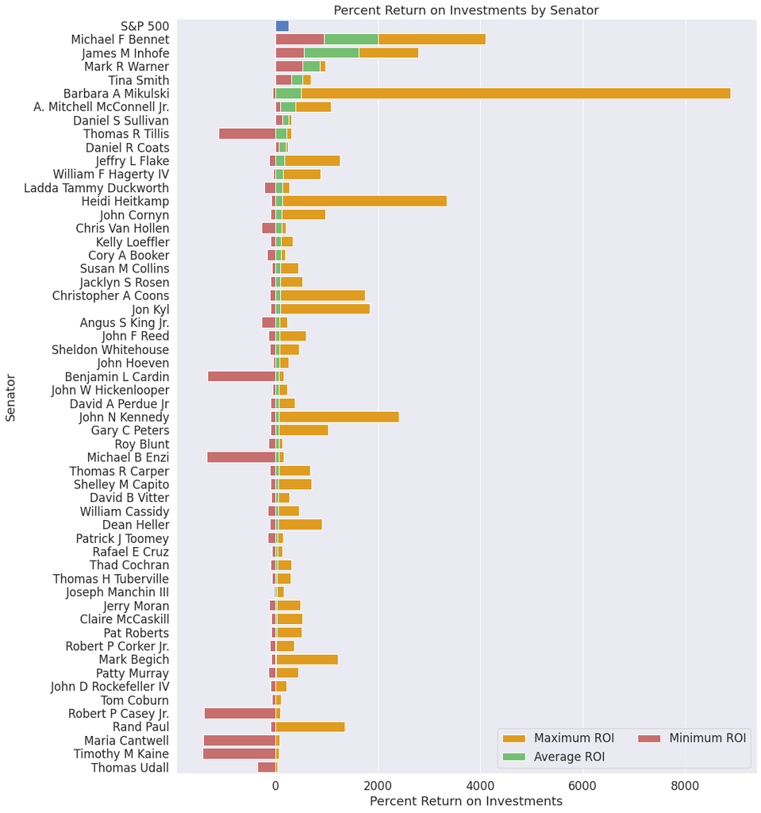

```python
# plot min, max, avg returns for all senators as well as the S&P 500
f, ax = plt.subplots(figsize=(15, 20))
sns.set_color_codes("muted")
sns.barplot(y=['S&P 500'] + list(sorted_max_roi.keys()), x=[0] + list(sorted_max_roi.values()), label='Maximum ROI', orient='h', color='orange')
sns.barplot(y=['S&P 500'] + list(sorted_avg_roi.keys()), x=[0] + list(sorted_avg_roi.values()), label='Average ROI', orient='h', color="g")
sns.barplot(y=['S&P 500'] + list(sorted_min_roi.keys()), x=[0] + list(sorted_min_roi.values()), label='Minimum ROI', orient='h', color='r')
sns.barplot(y=['S&P 500'] + list(sorted_min_roi.keys()), x=[sp500_change] + [0]*len(sorted_min_roi), orient='h', color="b")
ax.legend(ncol=2, loc="lower right", frameon=True)
ax.set(ylabel="Senator", xlabel="Percent Return on Investments", title='Percent Return on Investments by Senator')
```

Using liberal estimates, 38 senators beat the market (ROI > 252%).

```python
len([val for val in max_roi.items() if val[1] > sp500_change])
```

```
38
```

Using our average estimates, the seven senators below beat the S&P 500.

```python
[val for val in avg_roi.items() if val[1] > sp500_change]
```

```
[(' A. Mitchell McConnell Jr.', 392.7092354234115),
 (' Barbara A Mikulski', 498.8457609991058),
 (' Daniel S Sullivan', 257.79433766608923),
 (' James M Inhofe', 1624.869850122107),
 (' Mark R Warner', 868.0109398806682),
 (' Michael F Bennet', 1999.9880000799994),
 (' Tina Smith', 533.2333737994525)]
```

Even with the most conservative estimates of their returns, the four senators below beat the S&P 500.

```python
[val for val in min_roi.items() if val[1] > sp500_change]
```

```
[(' James M Inhofe', 553.846650964982),
 (' Mark R Warner', 530.4690056376435),
 (' Michael F Bennet', 950.003),
 (' Tina Smith', 310.2210358690841)]
```

The variation in these results points out some glaring flaws in the federal stock disclosure procedure. Because of the large ranges of transaction amounts, the actual amount that was traded can vary widely. From the above analysis, we see that only 7 senators beat the market with stock trades throughout the last 10 years using average estimates for the transaction amounts. However, that number skyrockets to 38 when using the upper end of the transaction ranges.

Because only a total of 55 senators report any transactions, the distinction between four and 38 senators outperforming the market is drastic. As previously stated, only 10% of active hedge fund managers beat their benchmark indicies.

## All Senators vs. S&P 500

```python
# sum the profits over all senators
min_senate_returns = sum([val for val in min_total_returns.values()])
max_senate_returns = sum([val for val in max_total_returns.values()])
avg_senate_returns = sum([val for val in avg_total_returns.values()])

# sum the costs over all senators
min_senate_cost = sum([val for val in min_cost.values()])
max_senate_cost = sum([val for val in max_cost.values()])
avg_senate_cost = sum([val for val in avg_cost.values()])

# print percent returns
print(f"Minimum (percent) return: {min_senate_returns/max_senate_cost:.2%}")
print(f"Average (percent) return: {avg_senate_returns/avg_senate_cost:.2%}")
print(f"Maxmum (percent) return: {max_senate_returns/min_senate_cost:.2%}")
```

```
Minimum (percent) return: -70.46%
Average (percent) return: 130.67%
Maxmum (percent) return: 469.65%
```

Senators may dramatically lose or dramatically make money from their stock trades depending on which estimates you use. It is also unclear whether they beat the market based on this data. In other words, the use of the ranges is almost fully obscuring the returns that senators make. This strongly suggests the need for reporting exact (or rounded) amounts of the trades rather than using wide ranges.

# Recommendations and Concluding Remarks

We offer the following recommendations regarding STOCK Act disclosures to improve transparency of congressional stock trading and the quality of data for future researchers. It is overall unclear whether senators are performing well enough to suggest dubious trading practices.

Perhaps the simplest solution to achieve higher confidence in Congress is to ban all individual stock trades to err on the side of caution, but due to the inconclusivity of our results, we focus our recommendations on updates to the disclosure requirements. We suggest the following steps to greatly improve the data quality as a means to increase transparency.

### Policy Recommendations

*Amount Ranges*  
One persistent struggle in this project has been the large ranges for the amount of each transaction.

- We would like to see requirements to report the exact amount (rounding is fine) so that we do not have to consider minimum, average, and maximum possible values of each of the quantities that we computed.
- As a computer scientist, it is tempting to try to apply a differential privacy approach to replace the amount ranges. However, the entire purpose of these disclosures is to pressure individuals not to make improper trades. Consequently, privacy is not a goal of these disclosures.

*Small Transactions*  
We frequently assumed that the disclosed transactions represented all of the transactions that occurred (for example when computing the number of shares retained).

- We would like to see requirements to report even trades under \$1000 so that these assumptions become valid.

*Exchanges*  
While exchanges did not represent a large portion of our data set, we still had to omit entries due to the challenge of incorporating inconsistent formats.

- We would like to see a consistent format for exchanges.
- The easiest solution seems to be requiring one entry for the old stock with the `Transaction_Type` "Exchange (Given)" and a corresponding entry for the new stock with "Exchange (Received)" in the action column.

*STOCK Act Enforcement*  
As mentioned in our introduction, Business Insider was unable to obtain confirmation from several senators that they paid the required fees (or obtained an ethics waiver) for late disclosures.

- In order for researchers (and the broader public) to have confidence that these disclosures are accurate, violations should be publicly recorded and fines strictly enforced.

*Brokered Trades*  
As mentioned in the **Comments on Comments** section, some trades indicate that a broker made the trade. Some Congress members use this as a defense against accusations that their trades are improper.

- `Stock Manager` should be a categorical column similar to the `Owner` column so that future researchers can determine if these trades perform significantly differently than the rest of the trades.
- Possible values could be `Self`, `Joint`, `Spouse`, `Dependent`, `Qualified Broker`, `Other`.

### Future Work

We find this to be an interesting area of research. As a result, we hope to see future work studying how the observed trends differ between parties, states, and clusters of senators. We are interested in extending this analysis to the disclosures for members of the House of Representatives and to financial assets other than stocks.  
A particularly interesting question that came out of this project is "how do stock returns correlate to seniority in Congress?" where seniority is measured by number of years in Congress and/or by the number/importance of committee appointments.  
We are also interested in whether transactions that were disclosed late perform differently than the average trade.

# Appendix

## Unique Comments

Below we show all 125 unique comments in the `trades` table.

```python
trades['Comment'].unique()
```

```
array(['--',
       'Agilent Tech common stock completed a spinoff on 10/22/14 to Keysight Tech',
       'KMB completed a spinoff of its health care business business now known as HYH on 11/01/14',
       'Dividend Reinvestment',
       '2015 Issued IR RSUs vested and actual shares issued; part of shares sold w/ remainder in UBS CSSP',
       '2016 Issued IR RSUs vested and actual shares issued; part of shares sold w/ remainder in UBS CSSP',
       'Transaction is due to sale of a security from redemption of incentive units vested on April 21, 2017',
       'Complete Disposition of Ingersoll Rand Stock',
       'Complete Disposition of Vulcan Materials Stock',
       'Mandatory Cash Merger',
       'WTR-Aqua America, Inc name change to WTRG-Essential Utilities, Inc on 2/3/2020.',
       "The filer's portfolio is managed by a third party investment professional. The filer was advised of these transactions on July 7, 2020. This activity is part of an ongoing long term portfolio diversification strategy that regularly includes similar transactions.",
       "The filer's portfolio is managed by a third party investment professional. The filer was advised of these transactions on April 7, 2020. This activity is part of an ongoing long-term portfolio diversification strategy that regularly includes similar transactions.",
       "The filer's portfolio is managed by a third party investment professional. The filer was advised of these transactions on June 2, 2020. This activity is part of an ongoing long-term portfolio diversification strategy that regularly includes similar transactions.",
       'Filer notified of transaction >45 days after it occurred.',
       "The filer's portfolio is managed by a third party investment professional. The filer was advised of these transactions on April 13, 2021. This activity is part of an ongoing long-term portfolio diversification strategy that regularly includes similar transactions",
       'This purchase is a reflection of Perdue exercising his stock option listed on previous disclosures',
       'Full sale from Wells Fargo Acct', 'Full sale of Wells Fargo Acct',
       'Full sale from Wells Fargo account.',
       'Quarterly dividend reinvestment',
       'Quarterly Dividend Reinvestment', 'R', 'SEP', 'Sep', 'Fr', 'FR',
       'Full sale from Wells Fargo Acct. This full sale was less than $1,000 but disclosing anyway for full transparency.',
       'sep',
       'This comment was incorrectly labeled as "partial" when it should have been labeled "full"',
       'This transaction was incorrectly labeled "partial" when it should have been labeled "full"',
       'This purchase initially listed the wrong ticker symbol and is now corrected',
       'Corrected the owner of the asset from "spouse" to "joint"',
       'Rate: 6.25% Maturation Date: 6/1/2035',
       'This asset was acquired through the reverse stock split from DowDuPont on June 3.',
       'Transaction incorrectly noted as partial sale. Corrected to display a purchase.',
       'Transaction incorrectly filed as a partial sale. Corrected to display purchase.',
       '20% Share in Brombach Family LP - Merrill Lynch',
       'The wrong ticker was used in the initial reporting of this transaction. The Vanguard Emerging Markets ticker was used instead of the Vanguard Ultra-Short Term Bond ticker.',
       'Less than $1001.', 'Purchase was less than $1001.',
       'Transaction was less than $1000',
       'Transaction was less than $1000.', 'Sale was less than $1000.',
       'Less than $1000', 'Less than $1000.',
       'Note: Transaction was less than $1,000.',
       'Note: This purchase was less than $1,000.',
       'Changed transaction date from 1/4/17 (Settlement date) to 12/29/16 (Trade date).',
```

[output cut: 53 more lines]

```
       'Asset held by Roundstone Ventures, LLC',
       'This transaction was filed on October 2 but was re-filed with the new system',
       'ESRX merged with CI, Cigna.',
       'Alcon Inc. (ALC) shares received in exchange for Novartis AG (NVS) shares as a result of spin-off.',
       'Exchange occurred as a result of the Sprint/T-Mobile merger.',
       'Shares of CTL received as a result of merger.',
       'Exchange of stock due to corporate merger.',
       'Exchange of stock due to corporate spin-off of the legacy assets and liabilities of NTRP not merged into PTPI.',
       'Exchange of stock due to partial corporate spin-off and renaming.',
       'Due to standing separation agreement with financial advisor, Senator first notified of activity 5/26/20 in compliance with Senate disclosure process.',
       "Post merger UTX changed it's name from United Technologies Corporation to Raytheon Technologies Corporation // Due to standing separation agreement with financial advisor, Senator first notified of activity 5/26/20 in compliance with Senate disclosure process.",
       'Merger - stock of Access National Corporation exchanged for Union Bankshares Corporation',
       'LIN acquired from PX due to mandatory stock merger.',
       'FLIR Systems Merger With Teledyne Asset Held in Roundstone Ventures, LLC'],
      dtype=object)
```